# Building Shiny Apps

MACS 30500 University of Chicago

## What is Shiny?

- R package from RStudio
- Web application framework for R
- R code $\rightarrow$ interactive web page
- No HTML/CSS/Javascript knowledge required
- Great for sharing R analysis with someone scared of R
- [Half your age plus seven](https://www.netflix.com/watch/70152033?t=420)
- [My Shiny app](https://bensoltoff.shinyapps.io/cfss-age-rule/)

## What is a Shiny app?

- Computer running R
- Web page
- Computer performs calculations, sends contents to web page
- User interacts with web page, sends updates back to computer
- Rinse and repeat

## City of Chicago wage employees

- [Dataset](https://data.cityofchicago.org/Administration-Finance/Current-Employee-Names-Salaries-and-Position-Title/xzkq-xp2w)
- [Final Shiny app](https://bensoltoff.shinyapps.io/chicago-employees/)

## Shiny app template

```r
library(shiny)
ui <- fluidPage()
server <- function(input, output) {}
shinyApp(ui = ui, server = server)
```

**Important**: Do not place any code after `shinyApp()`

## Run Shiny app in RStudio, method 1

Save file as **app.R** $\rightarrow$ “Run” button turns to “Run App”

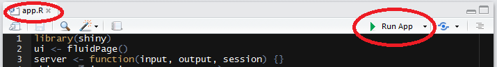

Good for creating Shiny apps quickly, all code in one file

## Run Shiny app in RStudio, method 2

Save UI as **ui.R** and server as **server.R** in **same directory**

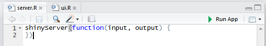

Good for complex Shiny apps, separates view vs logic

If using this method, **do not** include a call to `shinyApp(...)`

## Run Shiny app in RStudio, method 3

*File > New File > Shiny Web App…*

[figure not shown]

Generates the template for you

## Stop Shiny app in RStudio

Press “Esc” or click the *Stop* icon

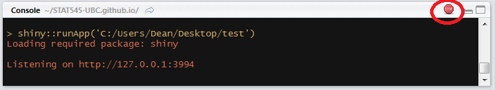

## Exercise: create the basic app

- Fork and clone [`shiny-demo`](https://github.com/uc-cfss/shiny-demo)
- Create a basic Shiny app
- Import the City of Chicago wage employee data file

## Add elements to app inside `fluidPage()`

```r
library(shiny)
ui <- fluidPage("Hello CFSS")
server <- function(input, output) {}
shinyApp(ui = ui, server = server)
```

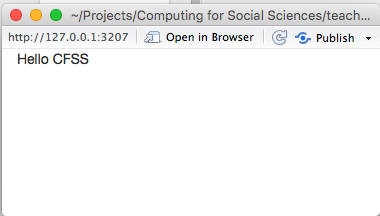

## Add elements to app inside `fluidPage()`

```r
fluidPage(
    h1("My Shiny app"),
    "Hello CFSS"
)
```

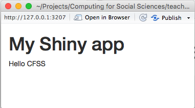

## Add HTML to `fluidPage()`

- Remember the UI simply creates HTML
- [Can use any HTML tags](http://shiny.rstudio.com/articles/tag-glossary.html)
  - `h1()` = header1
  - `br()` = line break
  - `strong()` = bold text
- Any HTML tag can be accessed using `tags` object
  - `h1` = `tags$h1()`, `br` = `tags$br()`
- Common tags can be accesed without `tags`

## Add HTML to `fluidPage()`

```r
fluidPage(
  h1("My Shiny app"),
  h3("Subtitle"),
  "Hello",
  "CFSS",
  br(),
  strong("bold text")
)
```

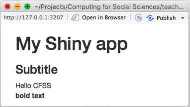

## Use a layout

- By default, all elements stack up one after the other
- [Can use different layouts](http://shiny.rstudio.com/articles/layout-guide.html)
- We’ll use `sidebarLayout()`

## `sidebarLayout()`

```r
fluidPage(
  titlePanel("My Shiny app"),
  sidebarLayout(
    sidebarPanel(
      "This is a side panel"
    ),
    mainPanel(
      "And this is the main stuff"
    )
  )
)
```

## `sidebarLayout()`

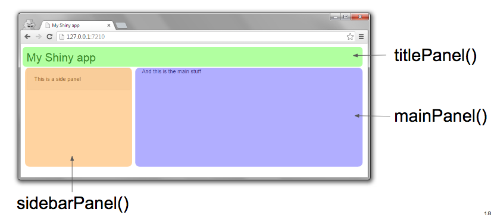

## Exercise: add a layout

- Define the layout for the application
- Add an app title
- Identify where inputs and outputs will go

## Inputs and outputs

- For interactivity, app needs inputs and outputs
- **Inputs** - things user can toggle/adjust
- **Output** - R objects user can see, often depend on inputs

```r
library(shiny)

ui <- fluidPage(
  sliderInput(
    "num", "Choose a number",
    min = 0, max = 100,
    value = 20)
)

server <- function(input, output) {}

shinyApp(ui = ui, server = server)
```

[figure not shown]

```r
sliderInput("num", "Choose a number",
            min = 0, max = 100, value = 20)
```

```r
print(sliderInput("num", "Choose a number",
            min = 0, max = 100, value = 20))
```

```
## <div class="form-group shiny-input-container">
##   <label class="control-label" for="num">Choose a number</label>
##   <input class="js-range-slider" id="num" data-min="0" data-max="100" data-from="20" data-step="1" data-grid="true" data-grid-num="10" data-grid-snap="false" data-prettify-separator="," data-prettify-enabled="true" data-keyboard="true" data-data-type="number"/>
## </div>
```

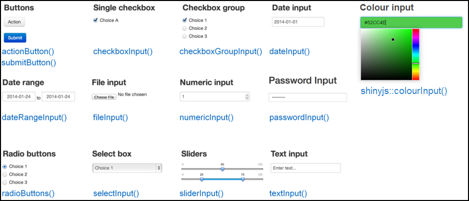

```r
sliderInput("num",
            "Choose a number",
            min = 0,
            max = 100,
            value = 20)
```

- Input name
- Label to display
- Input-specific arguments

## Exercise: add inputs

- Add inputs for
  - Wage
  - Full/part-time
  - Department

## Outputs

| Function | Outputs |
| --- | --- |
| `plotOutput()` | plot |
| `tableOutput()` | table |
| `uiOutput()` | Shiny UI element |
| `textOutput()` | text |

- Plots, tables, text - anything that R creates and users see
- Initialize as empty placeholder space until object is created

## Outputs

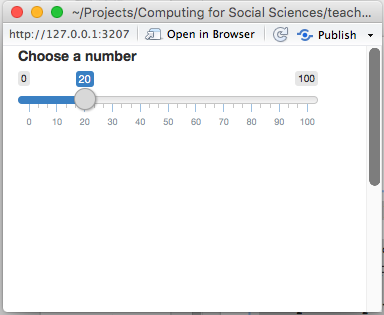

```r
library(shiny)

ui <- fluidPage(
  sliderInput("num", "Choose a number",
              0, 100, 20),
  plotOutput("myplot")
)

server <- function(input, output) {}

shinyApp(ui = ui, server = server)
```

## Exercise: add placeholders for output

- Add placeholders for a
  - Histogram
  - Table

## Server: assemble input into outputs with 3 rules

```r
server <- function(input, output) {
    output$myplot <- renderPlot({
        plot(rnorm(input$num))
    })
}
```

1. Save objects into `output$`
2. Build objects with `render*()`

## `Output()` $\rightarrow$ `render*()`

| Output function | Render function |
| --- | --- |
| `plotOutput()` | `renderPlot({})` |
| `tableOutput()` | `renderTable({})` |
| `uiOutput()` | `renderUI({})` |
| `textOutput()` | `renderText({})` |

## `render*()` functions build reactive output to display in UI

```r
renderPlot({
  plot(rnorm(100))
})
```

## Server: assemble input into outputs with 3 rules

```r
server <- function(input, output) {
    output$myplot <- renderPlot({
        plot(rnorm(input$num))

      # in UI:sliderInput("num", ...)
    })
}
```

1. Save objects into `output$`
2. Build objects with `render*()`
3. Access input values with `input$`

## Exercise: add output

- Create a histogram of hourly wages for selected employees
- Add a table showing the count of selected employees per department

## Reactivity

- Shiny uses **reactive programming**
- Reactive variables
  - When value of variable `x` changes, anything that relies on `x` is re-evaluated
  - Contrast with regular R:

    ```r
    x <- 5
    y <- x + 1
    x <- 10
    ```

## Reactivity

- `input$num` is a **reactive** value

  ```r
  output$myplot <- renderPlot({
    plot(rnorm(input$num))
  })
  ```

- `output$myplot` depends on `input$num`
  - `input$num` changes $\rightarrow$ `output$myplot` **reacts**
- All inputs are automatically reactive, so if you use any input inside a `render*` function, the output will re-render any time input changes

## Reactive contexts

- You can define your own reactive variables
- Reactive values can only be used inside **reactive contexts**
- Any `render*` function is a reactive context
- Use `reactive({...})` to assign a reactive variable
- Use `observe({...})` to access a reactive variable
- Remember: reactive variable means anything that depends on it gets re-executed automatically

## Reactive contexts

Assign variable

```r
server <- function(input, output) {
    x <- input$num + 1
}
# error
```

```r
server <- function(input, output) {
  x <- reactive({
    input$num + 1
  })
}
# OK
```

Access variable

```r
server <- function(input, output) {
    print(input$num)
}
# error
```

```r
server <- function(input, output) {
  observe({
    print(input$num)
  })
}
# OK
```

## Simple Shiny app using basic reactivity

```r
library(shiny)
ui <- fluidPage(
  sliderInput("num", "Choose a number",
              0, 100, 20),
  plotOutput("myplot")
)

server <- function(input, output) {
  output$myplot <- renderPlot({
    plot(seq(input$num))
  })
  x <- reactive({
    input$num + 1
  })
  observe({
    print(x())
  })
}

shinyApp(ui = ui, server = server)
```

## Exercise: make your code more efficient

- Create a reactive data frame `employ_filter` that creates the filtered data frame
- Use `employ_filter` to create the histogram and table

## Using uiOutput() to create UI elements dynamically

- `uiOutput()`
- Changing input values based on other inputs

## Basic example of uiOutput()

```r
library(shiny)
ui <- fluidPage(
  numericInput("num", "Maximum slider value", 5),
  uiOutput("slider")
)

server <- function(input, output) {
  output$slider <- renderUI({
    sliderInput("slider", "Slider", min = 0,
                max = input$num, value = 0)
  })
}

shinyApp(ui = ui, server = server)
```

## Exercise: Use `uiOutput()` in our app to populate the job titles

- Use `uiOutput()` in our app to populate the job titles input

## Share your app: shinyapps.io

- Go to http://www.shinyapps.io/ and make an account
- Make sure all your app files are in an isolated folder
- Click “Publish Application” in RStudio

[figure not shown]

  - You might be asked to install a couple packages
  - Follow instructions from RStudio